# Market Basket Analysis Tutorial

Linh Le - Analytics team

February 22, 2016

# 1 Định nghĩa

Market Basket Analysis là 1 phương pháp phân tích với mục đích là để tìm ra các tổ hợp sản phẩm hay được khách hàng mua cùng nhau

Ví dụ: khách hàng mua mỳ tôm thì thường cũng mua cả thịt bò khô và trứng

# 2 Các khái niệm cơ bản

- Rule: Nếu A, thì B
  $${i_{1},i_{2},...} => {i_{k}}$$
- Support：Giá trị Support của 1 sản phẩm hoặc 1 tổ hợp sản phẩm là tỷ lệ giữa số giao dịch chứa sản phẩm hoặc tổ hợp sản phẩm đó với tổng số giao dịch
  - Ví dụ: Một cửa hàng trong tháng 1 có 100 khách mua hàng. Trong đó 50 khách hàng mua sản phẩm A, 75 khách hàng mua sản phẩm B, và 25 khách hàng mua cả sản phẩm A và B
    - Support(sản phẩm A) = 50%
    - Support(Sản phẩm A, sản phẩm B) = 25%
- Confidence: Xác suất có điều kiện thể hiện khả năng khách hàng mua sản phẩm A cũng sẽ mua sản phẩm B. Giá trị confidence của 1 rule là khả năng rule đó sẽ xảy ra ở 1 giao dịch mới trong đó có chứa các sản phẩm ở vế bên trái của rule đó
  $$Confidence (i_{m} => i_{n}) = \frac{support(i_{m}\frown i_{n})}{support (i_{m})}$$
  - Ví dụ: Confidence (sản phẩm A , sản phẩm B) = 25/50 = 50%
    - Tức là nếu 1 người mua sản phẩm A, thì xác suất họ cũng mua sản phẩm B là 50%
- Lift: Nếu khách hàng mua sản phẩm A thì khả năng họ mua sản phẩm B sẽ tăng lên bao nhiêu %
  $$Lift(i_{m} => i_{n}) = \frac{support(i_{m}\frown i_{n})}{support(i_{m}) * support (i_{n})} = \frac{Confidence (i_{m} => i_{n})}{support (i_{n})}$$
  - Lift có thể cho 3 loại giá trị
    - Lift > 1: tức là những sản phẩm ở vế trái của rule sẽ làm tăng khả năng xảy ra của những sản phẩm ở vế phải của rule (2 sản phẩm bổ trợ)
    - Lift < 1: tức là những sản phẩm ở vế trái của rule sẽ làm giảm khả năng xảy ra của những sản phẩm ở vế phải của rule ( 2 sản phẩm thay thế được cho nhau)
    - Lift = 1: Các sản phẩm ở vế trái và vế phải xuất hiện độc lập với nhau, không rút ra được kết luận về rule
  - Ví dụ: Lift (sản phẩm A , sản phẩm B) = 50/75 = 0.67
    - Tức là nếu 1 người mua sản phẩm A, thì khả năng họ mua B giảm 33%

# 3 Cách làm Market Basket Analysis

- Sử dụng 2 gói package R: library (arules), library (arulesViz)
- Các bước thực hiện
  - B1: Đổi dữ liệu dataframe sang dạng transaction
    - Sử dụng hàm as() và split()
  - B2: Vẽ itemFrequencyPlot để xem những sản phẩm nào được mua nhiều nhất, chiếm bao nhiêu % của cả tập dữ liệu
  - B3: Dùng hàm apriori() để tìm ra các rules
  - B4: Trực quan hóa dữ liệu

```r
library(arulesViz)
plot(rules, method = "graph", interactive = TRUE, shading = NA)
```

# 4 3 câu hỏi trong Basket Analysis

Khi sử dụng Basket Analysis, có 3 câu hỏi thường gặp về mặt kinh doanh cần phải trả lời là:

- Các sản phẩm nào hay được mua cùng nhau?

```r
rules <- apriori(Groceries, parameter = list(supp = 0.001, conf = 0.5))
```

```
## Apriori
##
## Parameter specification:
##  confidence minval smax arem  aval originalSupport support minlen maxlen
##         0.5    0.1    1 none FALSE            TRUE   0.001      1     10
##  target   ext
##   rules FALSE
##
## Algorithmic control:
##  filter tree heap memopt load sort verbose
##     0.1 TRUE TRUE  FALSE TRUE    2    TRUE
##
## Absolute minimum support count: 9
##
## set item appearances ...[0 item(s)] done [0.00s].
## set transactions ...[169 item(s), 9835 transaction(s)] done [0.00s].
## sorting and recoding items ... [157 item(s)] done [0.00s].
## creating transaction tree ... done [0.00s].
## checking subsets of size 1 2 3 4 5 6 done [0.01s].
## writing ... [5668 rule(s)] done [0.00s].
## creating S4 object  ... done [0.00s].
```

```r
rules %>% sort(by = "lift") %>% head %>% inspect
```

```
##   lhs                        rhs                  support confidence     lift
## 1 {Instant food products,
##    soda}                  => {hamburger meat} 0.001220132  0.6315789 18.99565
## 2 {soda,
##    popcorn}               => {salty snack}    0.001220132  0.6315789 16.69779
## 3 {flour,
##    baking powder}         => {sugar}          0.001016777  0.5555556 16.40807
## 4 {ham,
##    processed cheese}      => {white bread}    0.001931876  0.6333333 15.04549
## 5 {whole milk,
##    Instant food products} => {hamburger meat} 0.001525165  0.5000000 15.03823
## 6 {other vegetables,
##    curd,
##    yogurt,
##    whipped/sour cream}    => {cream cheese }  0.001016777  0.5882353 14.83409
```

- Khách hàng mua sản phẩm A thì sẽ mua sản phẩm nào tiếp theo?

```r
rules <- apriori(data = Groceries,
                  parameter = list(supp = 0.001, conf = 0.15, minlen = 2),
                  appearance = list(default = "rhs", lhs = "whole milk"),
                  control = list(verbose = F)) # những người mua sữa thì cũng sẽ mua..
rules %>% sort(by = "lift") %>% head %>% inspect
```

```
##   lhs             rhs                support    confidence lift
## 2 {whole milk} => {root vegetables}  0.04890696 0.1914047  1.7560310
## 1 {whole milk} => {tropical fruit}   0.04229792 0.1655392  1.5775950
## 4 {whole milk} => {yogurt}           0.05602440 0.2192598  1.5717351
## 6 {whole milk} => {other vegetables} 0.07483477 0.2928770  1.5136341
## 5 {whole milk} => {rolls/buns}       0.05663447 0.2216474  1.2050318
## 3 {whole milk} => {soda}             0.04006101 0.1567847  0.8991124
```

- Khách hàng mua sản phẩm gì thì sẽ mua tiếp sản phẩm A?

```r
rules <- apriori(data = Groceries,
                 parameter = list(supp = 0.001, conf = 0.08),
                 appearance = list(default = "lhs", rhs = "whole milk"),
                 control = list(verbose = F)) # trước khi mua sữa nguyên kem thì người ta sẽ mua...
rules %>% sort(by = "lift") %>% head %>% inspect
```

```
##   lhs                     rhs              support confidence     lift
## 1 {rice,
##    sugar}              => {whole milk} 0.001220132          1 3.913649
## 2 {canned fish,
##    hygiene articles}   => {whole milk} 0.001118454          1 3.913649
## 3 {root vegetables,
##    butter,
##    rice}               => {whole milk} 0.001016777          1 3.913649
## 4 {root vegetables,
##    whipped/sour cream,
##    flour}              => {whole milk} 0.001728521          1 3.913649
## 5 {butter,
##    soft cheese,
##    domestic eggs}      => {whole milk} 0.001016777          1 3.913649
## 6 {pip fruit,
##    butter,
##    hygiene articles}   => {whole milk} 0.001016777          1 3.913649
```

# 5 Một vài lưu ý

- Cần loại bỏ các rule thừa (redundant)
  - Rule A được gọi 1 rule thừa, khi rule A là tập mẹ của 1 rule khác, và rule A có lift bằng hoặc thấp hơn so với rule đó.
  - Tức là: Với 2 rule {A,B,C} → {D} và {A,B} → {D}, thì {A,B,C} → {D} là rule thừa nếu có lift thấp hơn so với rule còn lại
    - Ví dụ:
      - milk => bread (12% support , 85% confidence, 1.2 lift)
      - milk, flavor = Chocolate => bread (1% support, 84% confidence, 1.15 lift)
  - Cách bỏ các rule thừa

```r
subset.matrix <- is.subset(rules, rules)
subset.matrix[lower.tri(subset.matrix, diag = T)] <- NA
redundant <- colSums(subset.matrix, na.rm = T) >= 1
which(redundant)
rules.pruned <- rules[!redundant]
rules <- rules.pruned
rules %>% sort(by = "lift") %>% head %>% inspect
```

# 6 Ví dụ trong dữ liệu thực tế của VPBank

```r
vidu.basket %>% head
```

```
##   target_id     cate
## 1   2531321 6011 ATM
## 2   1844232 6011 ATM
## 3   2712228 6011 ATM
## 4   1967283 6011 ATM
## 5   2854772 6011 ATM
## 6   3011976 6011 ATM
```

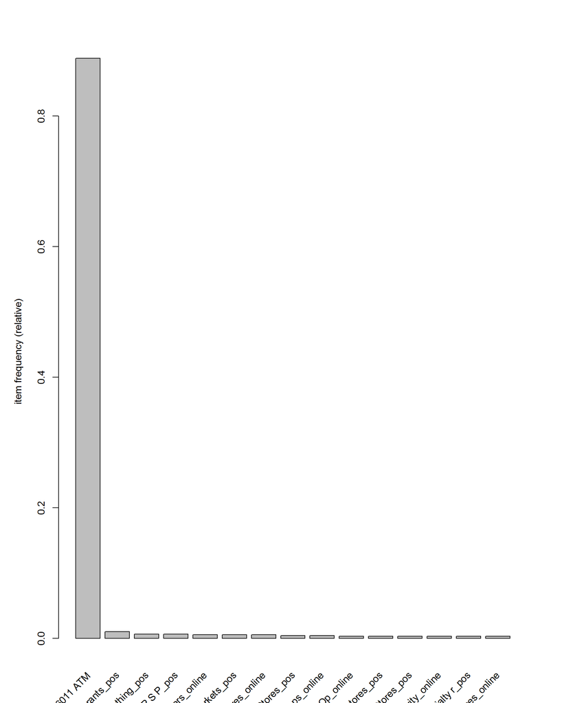

```r
# B1: Đổi dữ liệu dataframe sang dạng transaction

trans.combined <- split(vidu.basket$cate, vidu.basket$target_id)

trans.combined <- as(trans.combined, "transactions")

# B2: Vẽ Frequency Plot

itemFrequencyPlot(trans.combined,
                  topN = 15,
                  type = "relative",
                  mai = c(1,1,1,1))
```

```r
# B3: Tìm rule và hiển thị kết quả

rules <- apriori(trans.combined,
                 parameter = list(supp = 0.001, conf = 0.5))
```

```
## Apriori
##
## Parameter specification:
##  confidence minval smax arem  aval originalSupport support minlen maxlen
##         0.5    0.1    1 none FALSE            TRUE   0.001      1     10
##  target   ext
##   rules FALSE
##
## Algorithmic control:
##  filter tree heap memopt load sort verbose
##     0.1 TRUE TRUE  FALSE TRUE    2    TRUE
##
## Absolute minimum support count: 0
##
## set item appearances ...[0 item(s)] done [0.00s].
## set transactions ...[55 item(s), 868 transaction(s)] done [0.00s].
## sorting and recoding items ... [55 item(s)] done [0.00s].
## creating transaction tree ... done [0.00s].
## checking subsets of size 1 2 3 4 done [0.00s].
## writing ... [60 rule(s)] done [0.00s].
## creating S4 object  ... done [0.00s].
```

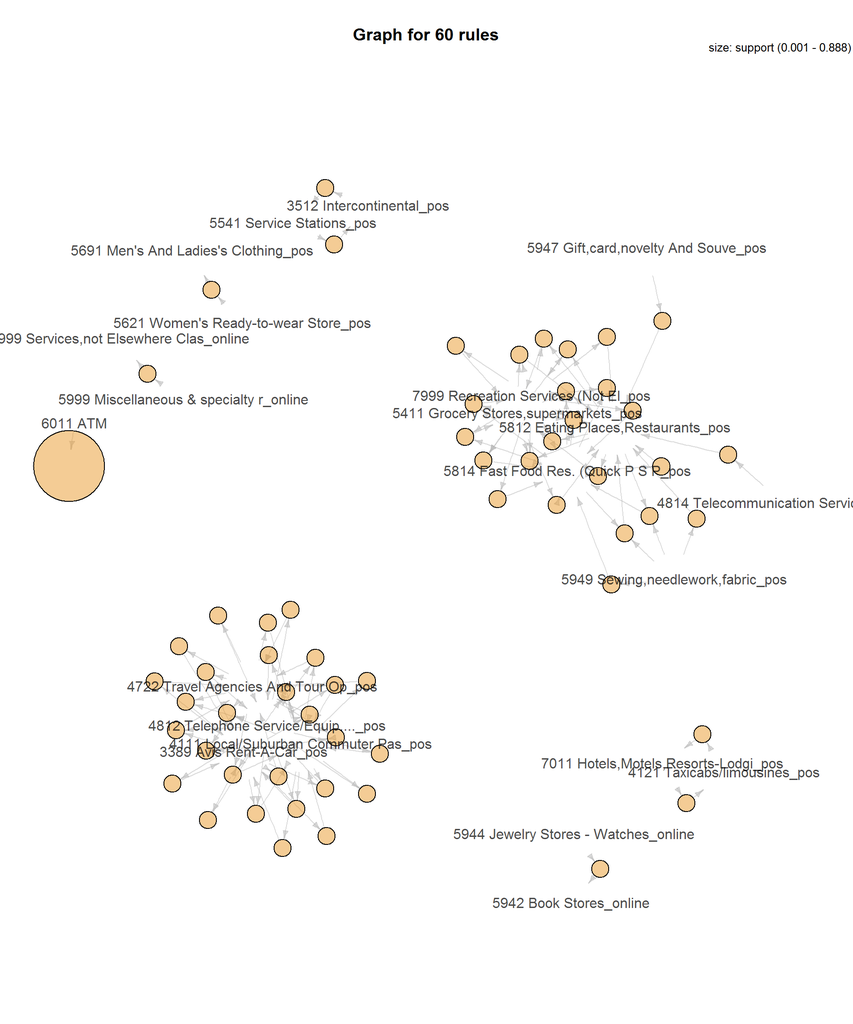

```r
rules <- sort(rules, by = "confidence", decreasing = TRUE)
plot(rules, method = "graph", interactive = FALSE, shading = NA)
```

```r
plot(rules, method = "graph", interactive = TRUE, shading = NA)
```

- Loại bỏ các rule thừa

```r
# B4: Loại bỏ các rule thừa
subset.matrix <- is.subset(rules, rules)
subset.matrix[lower.tri(subset.matrix, diag = T)] <- NA
redundant <- colSums(subset.matrix, na.rm = T) >= 1
which(redundant)[1:3]
```

```
##         {4121 Taxicabs/limousines_pos,7011 Hotels,Motels,Resorts-Lodgi_pos}
##                                                                           5
## {4722 Travel Agencies And Tour Op_pos,4812 Telephone Service/Equip...._pos}
##                                                                          13
## {4111 Local/Suburban Commuter Pas_pos,4812 Telephone Service/Equip...._pos}
##                                                                          15
```

```r
rules.pruned <- rules[!redundant]
rules.pruned %>% sort(by = "lift") %>% head %>% inspect
```

```
##   lhs                                       rhs                                        support confidence lift
## 1 {4121 Taxicabs/limousines_pos}         => {7011 Hotels,Motels,Resorts-Lodgi_pos} 0.001152074          1  868
## 2 {4812 Telephone Service/Equip...._pos} => {4722 Travel Agencies And Tour Op_pos} 0.001152074          1  868
## 3 {4812 Telephone Service/Equip...._pos} => {4111 Local/Suburban Commuter Pas_pos} 0.001152074          1  868
## 4 {4812 Telephone Service/Equip...._pos} => {3389 Avis Rent-A-Car_pos}             0.001152074          1  868
## 5 {4722 Travel Agencies And Tour Op_pos} => {4111 Local/Suburban Commuter Pas_pos} 0.001152074          1  868
## 6 {4722 Travel Agencies And Tour Op_pos} => {3389 Avis Rent-A-Car_pos}             0.001152074          1  868
```

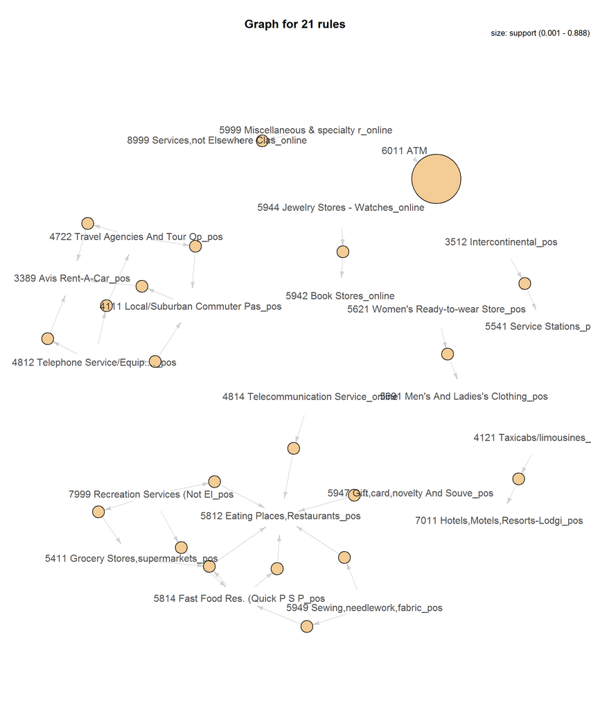

```r
plot(rules.pruned, method = "graph", interactive = FALSE, shading = NA)
```

# 7 Tài liệu đọc thêm

1. http://www.salemmarafi.com/code/market-basket-analysis-with-r/
2. http://brooksandrew.github.io/simpleblog/articles/association-rules-beyond-transactional-data/#validating-rules
3. http://www.listendata.com/2015/12/market-basket-analysis-with-r.html
4. http://rstatistics.net/association-mining-with-r/
5. http://paginas.fe.up.pt/~ec/files_1112/week_04_Association.pdf
6. http://snowplowanalytics.com/guides/recipes/catalog-analytics/market-basket-analysis-identifying-products-that-sell-well-together.html#arulesviz